# Análise de Dados de Produtos - Dashboard Interativo

Este projeto tem como objetivo realizar uma análise exploratória de um dataset de e-commerce, com foco na relação entre preço, desconto, avaliações e quantidade de vendas.

## Importação das Bibliotecas

Abaixo estão as bibliotecas utilizadas para construção do dashboard:

```python
import pandas as pd
import matplotlib.pyplot as plt
import seaborn as sns
```

## Geração dos gráficos

```python
df = pd.read_excel('ecommerce_estatistica.xlsx')
df.head()
```

|  | Unnamed: 0 | Título | Nota | N_Avaliações | Desconto | Marca | Material | Gênero | Temporada | Review1 | ... | Nota_MinMax | N_Avaliações_MinMax | Desconto_MinMax | Preço_MinMax | Marca_Cod | Material_Cod | Temporada_Cod | Qtd_Vendidos_Cod | Marca_Freq | Material_Freq |
| --- | --- | --- | --- | --- | --- | --- | --- | --- | --- | --- | --- | --- | --- | --- | --- | --- | --- | --- | --- | --- | --- |
| 0 | 1 | Kit 10 Cuecas Boxer Lupo Cueca Box Algodão Mas... | 4.5 | 3034 | 18 | lupo | algodão | Masculino Adulto | outono/inverno | As cuecas são boas; porém você percebe na cost... | ... | 0.814815 | 0.334178 | 0.213115 | 0.378585 | 463 | 25 | 3 | 10000 | 0.042292 | 0.176444 |
| 1 | 2 | Kit Com 10 Cuecas Boxer Algodão Sem Costura Zo... | 4.7 | 5682 | 20 | zorba | algodão | Masculino Adulto | não definido | O tecido é bom e são confortáveis. Só que a nu... | ... | 0.888889 | 0.625937 | 0.245902 | 0.322329 | 838 | 25 | 1 | 50000 | 0.009095 | 0.176444 |
| 2 | 3 | Kit 10 Cuecas Boxer Mash Algodão Cotton Box Or... | 4.6 | 1700 | 22 | mash | algodão | Masculino Adulto | primavera/verão | As cuecas são boas, porém meu marido usa g e p... | ... | 0.851852 | 0.187197 | 0.278689 | 0.372617 | 494 | 25 | 7 | 10000 | 0.010914 | 0.176444 |
| 3 | 4 | Kit 3 Short Jeans Feminino Cintura Alta Barato... | 4.4 | 507 | 9 | menina linda | jean | Feminino Adulto | primavera/verão | Estou encantada com essas peças!.\nOs shorts s... | ... | 0.777778 | 0.055751 | 0.065574 | 0.201767 | 509 | 74 | 7 | 1000 | 0.010005 | 0.025466 |
| 4 | 5 | Blusa + Calça Térmica Treino Futebol Criança I... | 4.7 | 58 | 5 | roupa zero grau | termico unissex | Sem gênero infantil | outono/inverno | Produto ótimo , mesmo após várias lavagens não... | ... | 0.888889 | 0.006280 | 0.000000 | 0.114508 | 669 | 166 | 3 | 100 | 0.002274 | 0.000910 |

5 rows × 24 columns

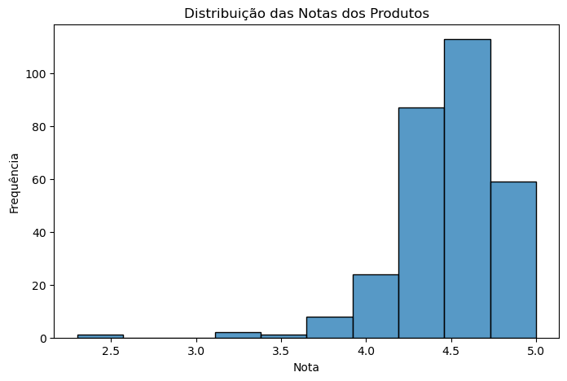

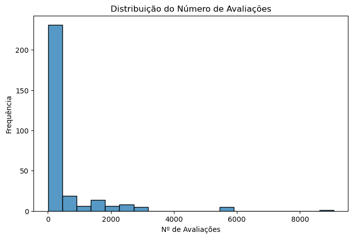

```python
plt.figure(figsize=(8,5))
sns.histplot(df['Nota'], bins=10, kde=False)
plt.title('Distribuição das Notas dos Produtos')
plt.xlabel('Nota')
plt.ylabel('Frequência')
plt.show()

plt.figure(figsize=(8,5))
sns.histplot(df['N_Avaliações'], bins=20, kde=False)
plt.title('Distribuição do Número de Avaliações')
plt.xlabel('Nº de Avaliações')
plt.ylabel('Frequência')
plt.show()
```

# 1. Histogramas

## a) Distribuição das Notas dos Produtos

Decisões:

Focar em campanhas de marketing para produtos bem avaliados (notas acima de 4.0) para impulsionar as vendas.

Investigar produtos com notas abaixo de 3.5 para identificar causas de avaliações negativas e buscar melhorias.

## b) Distribuição do Número de Avaliações

Poucos produtos recebem muitas avaliações, enquanto a maioria tem poucas. Isso aponta para uma concentração da visibilidade das avaliações em alguns produtos populares.

Decisões:

Promover os produtos com maior número de avaliações para alavancar vendas.

Incentivar os clientes a deixarem avaliações por meio de e-mails pós-compra ou benefícios.

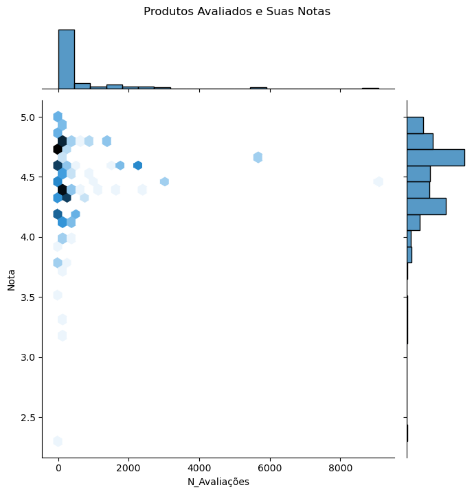

```python
plt.figure(figsize=(8,6))
sns.jointplot(
    data=df,
    x='N_Avaliações',
    y='Nota',
    kind='hex',
    height=7,
    marginal_kws=dict(bins=20, fill=True)
)
plt.suptitle('Produtos Avaliados e Suas Notas', y=1.02)
plt.show()
```

# 2. Gráfico de Dispersão – Relação entre Notas e Número de Avaliações

O padrão reforça a concentração de visibilidade e engajamento em poucos produtos populares, que recebem muitas avaliações.

Decisão:

Focar em estratégias para maximizar o engajamento nas avaliações desses produtos.

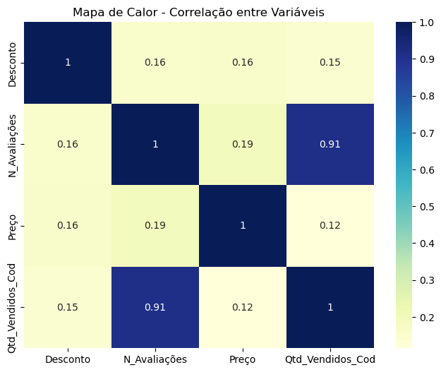

```python
plt.figure(figsize=(8,6))
corr = df[['Desconto', 'N_Avaliações', 'Preço', 'Qtd_Vendidos_Cod']].corr()
sns.heatmap(corr, annot=True, cmap='YlGnBu')
plt.title('Mapa de Calor - Correlação entre Variáveis')
plt.show()
```

# 3. Mapa de Calor – Correlação entre Desconto, Avaliações, Preço e Quantidade Vendida

Correlação forte (0.91) entre número de avaliações e quantidade vendida.

Correlação fraca (0.15) entre desconto e quantidade vendida.

Decisões:

Priorizar estratégias que incentivem avaliações.

Diversificar estratégias de vendas além de descontos, como frete grátis e programas de fidelidade.

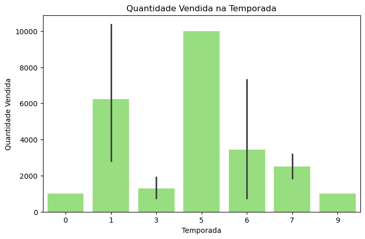

```python
plt.figure(figsize=(8,5))
sns.barplot(data=df, x='Temporada_Cod', y='Qtd_Vendidos_Cod', color='#90ee70')
plt.title('Quantidade Vendida na Temporada')
plt.xlabel('Temporada')
plt.ylabel('Quantidade Vendida')
plt.show()
```